# Larval respirometry (photosynthesis & respiration) with LoLinR

AS Huffmyer

2021

## Setup

Set up workspace, set options, and load required packages.

```r
knitr::opts_chunk$set(echo = TRUE, warning = FALSE, message = FALSE)
```

```r
## install packages if you dont already have them in your library
if ("devtools" %in% rownames(installed.packages()) == 'FALSE') install.packages('devtools')
library(devtools)
if ("segmented" %in% rownames(installed.packages()) == 'FALSE') install.packages('segmented')
if ("plotrix" %in% rownames(installed.packages()) == 'FALSE') install.packages('plotrix')
if ("gridExtra" %in% rownames(installed.packages()) == 'FALSE') install.packages('gridExtra')
if ("LoLinR" %in% rownames(installed.packages()) == 'FALSE') install_github('colin-olito/LoLinR')
if ("lubridate" %in% rownames(installed.packages()) == 'FALSE') install.packages('lubridate')
if ("chron" %in% rownames(installed.packages()) == 'FALSE') install.packages('chron')
if ("plyr" %in% rownames(installed.packages()) == 'FALSE') install.packages('plyr')
if ("dplyr" %in% rownames(installed.packages()) == 'FALSE') install.packages('dplyr')
if ("stringr" %in% rownames(installed.packages()) == 'FALSE') install.packages('stringr')
if ("Rmisc" %in% rownames(installed.packages()) == 'FALSE') install.packages('Rmisc')


#load packages
library("ggplot2")
library("segmented")
library("plotrix")
library("gridExtra")
library("LoLinR")
library("lubridate")
library("chron")
library('plyr')
library('dplyr')
library('stringr')
library('Rmisc')
```

## Respirometry in LoLinR

Modified from K. Wong, S. Gurr, H. Putnam scripts

Set the path of all respirometry files within the R project.

```r
path.p<-"Pacu2021/Data/Respiration/TPC/Runs" #location of files
```

Bring in the file names.

```r
# bring in the respiration file names
file.names<-basename(list.files(path = path.p, pattern = "csv$", recursive = TRUE)) #list all csv file names in the folder and subfolders
```

Generate respiration data frames.

```r
#generate a 6 column dataframe with specific column names
#respiration
Resp.R <- data.frame(matrix(NA, ncol=6))
colnames(Resp.R) <- c("Date", "Run","Sample.ID","Chamber.ID","Intercept", "umol.L.min")

Resp.Rb <- data.frame(matrix(NA, ncol=6))
colnames(Resp.Rb) <- c("Date", "Run","Sample.ID","Chamber.ID","Intercept", "umol.L.min")

#photosynthesis
Photo.R <- data.frame(matrix(NA, ncol=6))
colnames(Photo.R) <- c("Date", "Run","Sample.ID","Chamber.ID","Intercept", "umol.L.min")

Photo.Rb <- data.frame(matrix(NA, ncol=6))
colnames(Photo.Rb) <- c("Date", "Run", "Sample.ID","Chamber.ID","Intercept", "umol.L.min")
```

Load in the sample information file. It is important to have chambers in the order “A1, B1, C1, D1”, rather than “A1, A2, A3, A4”.

```r
Sample.Info<-read.csv("Pacu2021/Data/Respiration/TPC/Resp_Sample_Info_TPC.csv") #information on life stage, number of individuals, runs, etc.
rename <- Sample.Info$Chamber.ID
samp <- Sample.Info$Sample.ID
run <- str_sub(file.names, 10, 13) #grab run from file name
date <- str_sub(file.names, 1, str_length(file.names)-29) #grab date from file name

#load in respiration start times as a list the same length as the number of files
starttimes<-read.csv("Pacu2021/Data/Respiration/TPC/starttimes_TPC.csv") #read in file of starting R and P phase times
rtime<-starttimes$Rtime #list respiration start times. For respiration measurements, filter as > than this time
ptime<-starttimes$Ptime #for photosynthesis, filter as < than this time
```

Run loop to extract slopes from respiration data. Subset for respiration data by filtering time >= respiration start time. Start and end time datasheet has removed first 5 minutes of each run to allow for temp equilibration.

```r
for(i in 1:length(file.names)) { # for every file in list start at the first and run this following function
  Resp.Data <-read.table(file.path(path.p,file.names[i]), skip = 72, header=T, sep=",", na.string="NA", fill = TRUE, as.is=TRUE, fileEncoding="latin1") #reads in the data files
  Resp.Data$Temp <- Resp.Data[,31] #assigns temp column
  Resp.Data$Time.Min <- seq.int(0.017, (nrow(Resp.Data))*0.25, by = 0.25) #set time in min
  Resp.Data <- Resp.Data %>% #filters data by phase (respiration only)
     filter(Time.Min > rtime[i])
  Resp.Data.N <- Resp.Data[,3:25] #subset desired columns

  for(j in 1:(ncol(Resp.Data.N))){
    model <- rankLocReg(
      xall=Resp.Data$Time.Min, yall=as.numeric(Resp.Data.N[, j]),
      alpha=0.4, method="pc", verbose=TRUE) #extract slopes, percentile rank method with minimum window size of 0.4. This means that in order to fit a slope, it has to encompass at least 40% of available datapoints.

    pdf(paste0("Pacu2021/Output/Respiration/TPC/RespirationPlots/",date[i], "_",run[i],"_",rename[j],"_regression_trunc.pdf")) #generate output file names
    plot(model)
    dev.off()

    Resp.Rb[j,1] <- as.character(date[i]) #stores the date
    Resp.Rb[j,2] <- as.character(run[i]) #stores the run number
    Resp.Rb[j,3] <- as.character(samp[j+(i-1)*ncol(Resp.Data.N)]) #stores the sample ID
    Resp.Rb[j,4] <- as.character(rename[j]) #stores the chamber ID
    Resp.Rb[j,5:6] <- model$allRegs[i,c(4,5)] #inserts slope and intercept in the dataframe

  }
  Resp.R <- rbind(Resp.R, Resp.Rb) #bind final data frame
}
```

Removed column B6 due to missing sensor. This column had to be removed from data sheets due to ‘no sensor’ reading that stops the code.  
Save respiration data frames.

```r
Resp.R <- Resp.R[-1,] #remove empty column

write.csv(Resp.R, paste0("Pacu2021/Output/Respiration/TPC/Respiration_rates_Pacu2021.csv", sep="")) #save respiration rate data
```

```r
Resp.Rates <- read.csv(file = "Pacu2021/Output/Respiration/TPC/Respiration_rates_Pacu2021.csv") #read file back in so slopes don't have to be generated every time
Resp.Rates = subset(Resp.Rates, select = -c(X) ) #remove empty column

#format "run" column
Resp.Rates<-Resp.Rates %>%
  mutate(Run = str_sub(Run, 4, -1))
Resp.Rates$Run<-as.factor(Resp.Rates$Run) #format as # rather than run #, set as integer
```

Merge R files with sample info for testing and manipulation.

```r
Sample.Info$Run<-as.factor(Resp.Rates$Run)
oxygen<-full_join(Sample.Info, Resp.Rates) #add respiration data
colnames(oxygen)[colnames(oxygen) == 'Intercept'] <- 'Resp.Intercept' #rename to specify R
colnames(oxygen)[colnames(oxygen) == 'umol.L.min'] <- 'R.umol.L.min' #rename to specify R
```

Remove wells that slope extraction does not match data (multiple peaks, wells with issues).

```r
oxygen$code<-paste(oxygen$Run, oxygen$Chamber.ID)
remove<-c("2 A1", "2 C1", "3 A4", "4 D3", "6 A3", "6 B3", "7 C4", "8 D1", "B A2", "C A1", "C A2")
oxygen<-oxygen%>%
  filter(!code %in% remove)
```

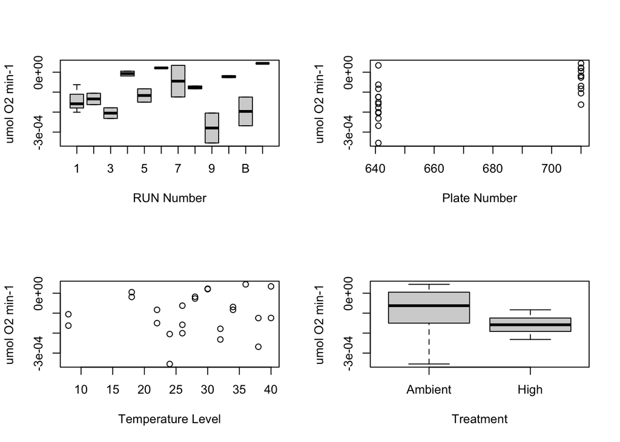

```r
#Account for chamber volume to convert from umol L-1 m-1 to umol m-1. This standardizes across water volumes (different because of coral size) and removes per Liter
oxygen$R.umol.min <- oxygen$R.umol.L.min * oxygen$Volume #calculate

blank_data <- subset(oxygen, Type == "Blank") #subset to blank data only
par(mfrow=c(2,2))
plot(as.factor(blank_data$Run),blank_data$R.umol.min, ylab="umol O2 min-1", xlab="RUN Number") #blanks during dark phase
plot(blank_data$Plate, blank_data$R.umol.min, ylab="umol O2 min-1",, xlab="Plate Number") #blanks during dark phase
plot(blank_data$Temperature, blank_data$R.umol.min, ylab="umol O2 min-1",xlab="Temperature Level") #blanks during dark phase
plot(as.factor(blank_data$Treatment), blank_data$R.umol.min, ylab="umol O2 min-1", xlab="Treatment") #blanks during dark phase
```

```r
#display mean blankvalues
mean(blank_data$R.umol.min) #mean R phase blanks
```

```
## [1] -0.0001040989
```

```r
resp.blnk <- aggregate(R.umol.min ~ Date*Run, data=blank_data, mean) #calculate average blank for each run
colnames(resp.blnk)[colnames(resp.blnk) == 'R.umol.min'] <- 'R.Blank.umol.min' #rename to specify blank for R

oxygen <- full_join(oxygen, resp.blnk) #add R blanks to master
```

```r
oxygen$R.umol.min.corr<-oxygen$R.umol.min-oxygen$R.Blank.umol.min #subtract R blanks
```

Normalize to biologically relevant measure. Here, normalize to number of larvae. This can be substituted or changed for larval size/volume as well.

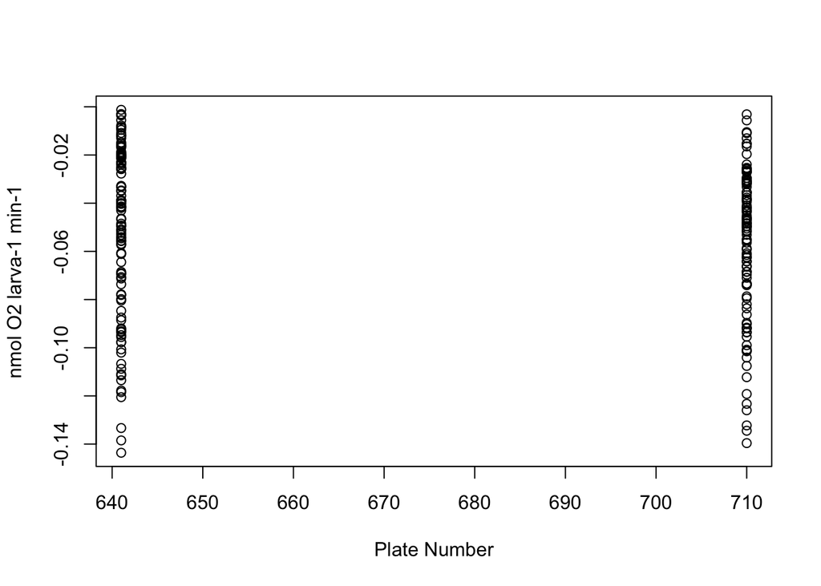

```r
oxygen.bio <- oxygen %>% filter(Type == "Sample") #isolate only biological samples and drop unused factor levels
oxygen.bio <- droplevels(oxygen.bio) #drop unused factor levels

#respiration
oxygen.bio$R.umol.org.min <- oxygen.bio$R.umol.min.corr/oxygen.bio$Org.Number #calculate oxygen per organism (larvae or recruit)
#oxygen.bio$R.umol.org.min <- oxygen.bio$R.umol.org.sec*60 #calculate oxygen per organism per minute - not used in this script
oxygen.bio$R.nmol.org.min <- oxygen.bio$R.umol.org.min*1000 #calculate nanmoles
#oxygen.bio$R.nmol.total.min <- oxygen.bio$R.nmol.org.min*oxygen.bio$Org.Number #calculate total gross photosynthesis (not normalized to number of organisms)

#Save as .csv file.
write.csv(oxygen.bio, paste0("Pacu2021/Output/Respiration/TPC/oxygen_Resp_rates.csv", sep="")) #save final file


#Visualize Data
oxygen.bio2 <- oxygen.bio %>% filter(R.nmol.org.min<0)
oxygen.bio2 <- oxygen.bio2 %>% filter(R.nmol.org.min>-0.15)

#par(mfrow=c(2,2))
plot(oxygen.bio2$Plate, oxygen.bio2$R.nmol.org.min , ylab="nmol O2 larva-1 min-1",xlab="Plate Number") #blanks during dark phase
```

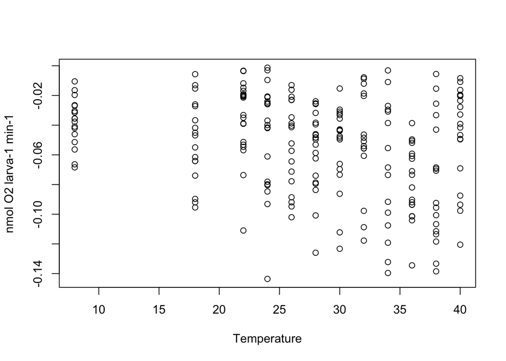

```r
plot(oxygen.bio2$Temperature, oxygen.bio2$R.nmol.org.min , ylab="nmol O2 larva-1 min-1",xlab="Temperature") #blanks during dark phase
```

Save as .csv file.

```r
write.csv(oxygen.bio, paste0("Pacu2021/Output/Respiration/TPC/oxygen_Resp_rates_filtered.csv", sep="")) #save final file
```